# Business Insights Report

Data Visualization and Communication

Eldhose Anil–665769493

2025-12-06

# 1 Data Exploration and Setup

```r
# Load ggplot2
library(ggplot2)

# Load the business dataset
business_data <- read.csv("data/business_performance.csv")
```

```r
str(business_data)
```

```
## 'data.frame':    48 obs. of  7 variables:
##  $ quarter        : chr  "Q1" "Q2" "Q3" "Q4" ...
##  $ channel        : chr  "Online" "Online" "Online" "Online" ...
##  $ year           : int  2023 2023 2023 2023 2023 2023 2023 2023 2023 2023 ...
##  $ revenue        : int  314019 288825 296739 287699 351721 324090 348699 328609 368558 362724 ...
##  $ customers      : int  1200 1340 1405 1241 1441 1647 1650 1556 1524 1690 ...
##  $ conversion_rate: num  3.9 3.4 2.9 3.6 NA 3.8 3.4 3.7 4.3 3.6 ...
##  $ region         : chr  "North" "South" "East" "West" ...
```

```r
summary(business_data)
```

```
##    quarter            channel               year         revenue
##  Length:48          Length:48          Min.   :2023   Min.   :150231
##  Class :character   Class :character   1st Qu.:2023   1st Qu.:177597
##  Mode  :character   Mode  :character   Median :2024   Median :263544
##                                        Mean   :2024   Mean   :258796
##                                        3rd Qu.:2024   3rd Qu.:324372
##                                        Max.   :2024   Max.   :412125
##
##    customers    conversion_rate    region
##  Min.   : 433   Min.   :2.300   Length:48
##  1st Qu.: 600   1st Qu.:3.100   Class :character
##  Median :1223   Median :3.700   Mode  :character
##  Mean   :1127   Mean   :3.849
##  3rd Qu.:1526   3rd Qu.:4.400
##  Max.   :1861   Max.   :6.400
##                 NA's   :3
```

```r
aggregate(revenue ~ channel, data = business_data, sum)
```

```
##   channel revenue
## 1  Mobile 4158056
## 2  Online 5571130
## 3  Retail 2693023
```

```r
aggregate(customers ~ quarter, data = business_data, mean)
```

```
##   quarter customers
## 1      Q1  1069.000
## 2      Q2  1153.583
## 3      Q3  1172.917
## 4      Q4  1110.750
```

The online channel generates the most revenue overall, with revenue of 5571130. Q3 typically has the most customers, with an average of 1172.917.

```r
business_data$revenue_per_customer <- business_data$revenue / business_data$customers

aggregate(revenue_per_customer ~ channel, data = business_data, mean)
```

```
##   channel revenue_per_customer
## 1  Mobile             202.8074
## 2  Online             224.3320
## 3  Retail             314.2239
```

The retail channel has the highest average revenue per customer, with a figure of 314.2239. This provides business insight into understanding customers in different channels, showing that each retail customer contributes the most out of all channels. This insight can be used to strengthen and focus business efforts with these groups.

# 2 Business Visualizations

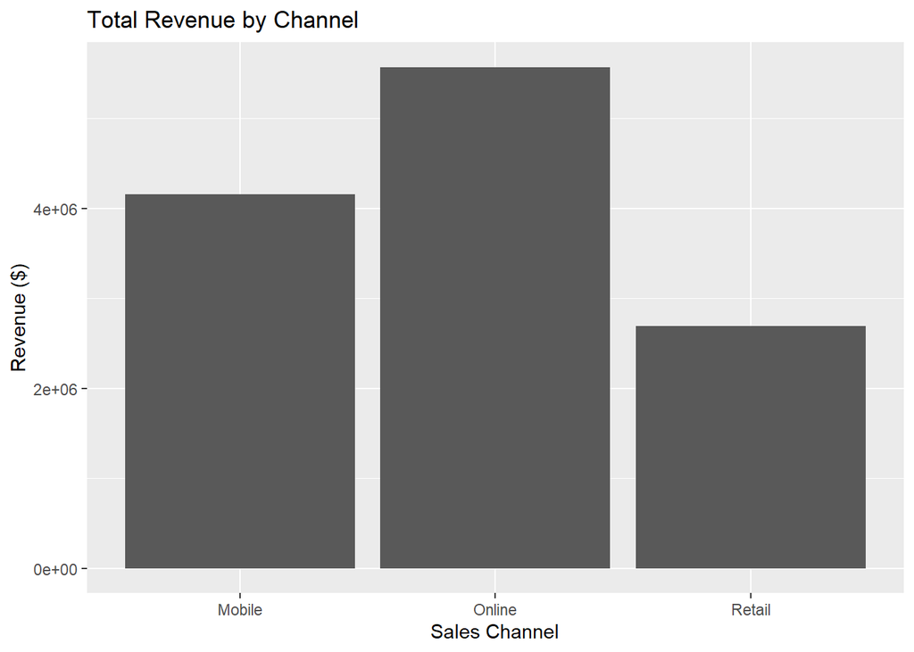

```r
# Calculate totals first
channel_totals <- aggregate(revenue ~ channel, data = business_data, sum)
# Then create the chart
ggplot(channel_totals, aes(x = channel, y = revenue)) +
  geom_bar(stat = "identity") +
  labs(title = "Total Revenue by Channel",
       x = "Sales Channel", y = "Revenue ($)")
```

Based on this bar chart, the online channel should receive more investment, as it demonstrates the highest total revenue.

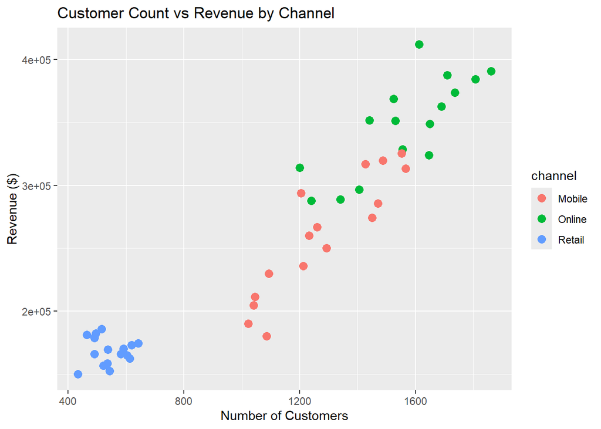

```r
ggplot(business_data, aes(x = customers, y = revenue, color = channel)) +
  geom_point(size = 3) +
  labs(title = "Customer Count vs Revenue by Channel",
       x = "Number of Customers", y = "Revenue ($)")
```

# 3 Strategic Recommendations

```r
library(knitr)

# Create executive dashboard

total_revenue <- aggregate(cbind(revenue) ~ channel,
                                 data = business_data,
                                 FUN = sum
                                 )

average_customers <- aggregate(cbind(customers) ~ channel,
                                 data = business_data,
                                 FUN = mean
                                 )

average_conversion_rate <- aggregate(cbind(conversion_rate) ~ channel,
                                 data = business_data,
                                 FUN = mean
                                 )

performance_summary <- merge(total_revenue, average_customers, by = "channel")

performance_summary <- merge(performance_summary, average_conversion_rate, by = "channel")

kable(performance_summary,
      col.names = c("Channel", "Total Revenue ($)", "Average Customers", "Average Conversion Rates"),
      digits = 6,
      caption = "Performance Summary")
```

Performance Summary

| Channel | Total Revenue ($) | Average Customers | Average Conversion Rates |
| --- | --- | --- | --- |
| Mobile | 4158056 | 1278.0625 | 2.880000 |
| Online | 5571130 | 1559.5625 | 3.640000 |
| Retail | 2693023 | 542.0625 | 5.026667 |

Based on the analysis of included business data with visualization, it seems beneficial to currently concentrate investing on the online channel, as the online channel demonstrates the highest total revenue, with $5,571,130 and highest average customers of 1559.5625. Therefore, strengthening sales and marketing in the online channel proves as a reliable way to increase profit.